# Seafood Engine: knowledge base

NSF Regional Innovation Engines, Cohort 2. Technology profile v3.1. Draft, in progress

**NSF Seafood Engine in New England (NSPIRE)**, led by Northeastern Regional Association of Coastal Ocean Observing Sys. NSF award 2532447, start September 2026. Search window for papers and patents: from September 2021 (five years before the award) onward.

## At a glance

| Measure | Value |
| --- | --- |
| People named by NSF or the Engine’s site | 16 |
| of them active researchers (>= 5 works since window start) | 7 |
| Team members who are inventors (2021-2025 grants, in the region) | 1 |
| Partners (site list + team members’ organisations) | 15 |
| Knowledge-producer partners (universities, labs, institutes) | 9 |
| Partner papers in the Engine’s topics | 941 |
| of them with an in-region partner | 651 |
| Regional patents in the technology profile (2021-2025 grants) | 46 |
| Location quotient of the technology profile (patents) | 1.02 |
| Share of regional technology patents owned by partners | 0.0% |

## Economic base

| NAICS | Industry | Employment in region | Establishments | Share of US employment | Employment LQ |
| --- | --- | --- | --- | --- | --- |
| 1141 | Fishing | 789 | 650 | 17.2% | 4.71 |
| 3117 | Seafood product preparation and packaging | 2,894 | 58 | 9.9% | 2.72 |
| 4244 | Grocery and related product merchant wholesalers (incl. fish and seafood) | 28,788 | 1,268 | 3.3% | 0.90 |

Industries related to the Engine’s technology (chosen from the NSF abstract, see `data/manual/engine_naics.csv`). County Business Patterns 2023; LQ = the industry’s share of regional employment relative to its share of US employment (1 = US average). Region: whole state(s).

## Technology profile

Version 3.1, core. The NSF abstract names 4 technologies of this Engine (scientific and technical fragments extracted with a fixed prompt; the extraction was done by hand in a chat session, not reproducible). For each technology, all 4,516 OpenAlex topics and all CPC main groups are ranked by several independent signals; the core keeps up to 2 topics and 2 CPC main groups per technology. *Judge*: chosen by a rubric judge where no candidate was confirmed by two kinds of evidence (also by hand in a chat session). An empty cell: no suitable item among the candidates. See Methodology and the comparison of versions.

| # | Technology | OpenAlex topics | CPC main groups |
| --- | --- | --- | --- |
| 1 | seafood products, processing technologies and waste stream utilization | T14010 Food Industry and Aquatic Biology | A23L17/00 Food-from-the-sea products; Fish products; Fish meal; Fish-egg substitutes; Preparation or treatment thereof (judge) A22C29/00 Processing shellfish or bivalves, e.g. oysters, lobsters; Devic… |
| 2 | ocean observation technologies for fishing grounds and aquaculture farms | T10230 Marine and fisheries research |  |
| 3 | cold chain technologies | T12486 Food Supply Chain Traceability T14479 Freezing and Crystallization Processes | F25D13/00 Stationary devices, e.g. cold-rooms (judge) F25D3/00 Devices using other cold materials; Devices using cold-storage bodies (judge) |
| 4 | traceability technologies | T12486 Food Supply Chain Traceability |  |

## People

| Role | People |
| --- | --- |
| organizer | 9 |
| researcher | 7 |

| Name | Role | On NSF award | Title | Organisation | Works since window (in Engine topics) | h-index | Patents 2021-25 (in Engine profile) | Site | OpenAlex |
| --- | --- | --- | --- | --- | --- | --- | --- | --- | --- |
| Diane Foster | researcher |  |  | Woods Hole Oceanographic Institution | 9 (0) | 19 |  | [page](https://seafoodengine.org/leadership/) | [profile](https://openalex.org/A5026869288) |
| Hanumant Singh | researcher | Co-PI |  | Northeastern University | 35 (1) | 59 |  | [page](https://seafoodengine.org/leadership/) | [profile](https://openalex.org/A5047246028) |
| Janet Duffy-Anderson | researcher | Co-PI |  | Gulf of Maine Research Institute | 18 (13) | 31 |  | [page](https://seafoodengine.org/leadership/) | [profile](https://openalex.org/A5046223271) |
| Julia Melkers | researcher |  |  | Arizona State University | 15 (0) | 24 |  | [page](https://seafoodengine.org/leadership/) | [profile](https://openalex.org/A5081381252) |
| Kevin Stokesbury | researcher | Co-PI |  | University of Massachusetts-Dartmouth | 24 (19) | 22 |  | [page](https://seafoodengine.org/leadership/) | [profile](https://openalex.org/A5062143062) |
| Marta Gomez-Chiarri | researcher | Co-PI |  | University of Rhode Island | 40 (1) | 36 | 1 (0) | [page](https://seafoodengine.org/leadership/) | [profile](https://openalex.org/A5015590914) |
| Michael Chambers | researcher |  |  | University of New Hampshire | 18 (0) | 14 |  | [page](https://seafoodengine.org/leadership/) | [profile](https://openalex.org/A5015247895) |
| Ben Martens | organizer |  |  | Maine Coast Fishermen’s Association | - | - |  | [page](https://seafoodengine.org/leadership/) |  |
| Erik Chapman | organizer |  |  | New Hampshire Sea Grant | 0 | 5 |  | [page](https://seafoodengine.org/leadership/) | [profile](https://openalex.org/A5074512054) |
| Fred Mattera | organizer |  |  | Commercial Fisheries Center of Rhode … | - | - |  | [page](https://seafoodengine.org/leadership/) |  |
| Jake Kritzer | organizer | PI | Chief Executive Officer | NERACOOS | - | - |  | [page](https://seafoodengine.org/leadership/) |  |
| Julie Demers | organizer |  |  | New Hampshire Tech Alliance | - | - |  | [page](https://seafoodengine.org/leadership/) |  |
| Lisa Carnevale | organizer |  |  | Ocean Tech Hub | - | - |  | [page](https://seafoodengine.org/leadership/) |  |
| Mel Sanderson | organizer |  |  | Cape Cod Commercial Fishermen’s Alliance | - | - |  | [page](https://seafoodengine.org/leadership/) |  |
| Nick Rotker | organizer |  |  | MITRE Corporation | - | - |  | [page](https://seafoodengine.org/leadership/) |  |
| Tracey Dalton | organizer |  |  | Rhode Island Sea Grant | - | - |  | [page](https://seafoodengine.org/leadership/) |  |

Publication counts are shown only where the OpenAlex author matches both the name and the person’s current organisation. The OpenAlex link is given only for these reliable matches, and not for profiles flagged as possibly merging several namesakes. *Site* links to the page of the Engine’s website where the person is named. Click a number of works to see the list on the Publications page. *Patents*: US grants 2021-2025 with the person among the inventors (same last and first name, address in the Engine’s states); click the number for the list on the Patents page. In brackets: works in the Engine’s topics, patents with a CPC code in the Engine’s technology profile.

## Researchers at partner organisations

| # | Researcher | Partner | Works in the Engine’s topics | Citations | Years | Most cited of these works |
| --- | --- | --- | --- | --- | --- | --- |
| 1 | [Camrin D. Braun](https://openalex.org/A5083624621) | Woods Hole Oceanographic Institution | 38 | 814 | 2021-2026 | [Anticyclonic eddies aggregate pelagic predators in a subt…](https://openalex.org/W4294904444) |
| 2 | [Katherine E. Mills](https://openalex.org/A5001996124) | Gulf of Maine Research Institute | 38 | 795 | 2021-2026 | [Attributes of climate resilience in fisheries: From theor…](https://openalex.org/W3215312455) |
| 3 | [Martin Christopher Arostegui](https://openalex.org/A5001339437) | Woods Hole Oceanographic Institution | 29 | 533 | 2022-2026 | [Anticyclonic eddies aggregate pelagic predators in a subt…](https://openalex.org/W4294904444) |
| 4 | [Steven X. Cadrin](https://openalex.org/A5027011805) | University of Massachusetts-Dartmouth | 26 | 330 | 2021-2026 | [Best practices for defining spatial boundaries and spatia…](https://openalex.org/W4320085849) |
| 5 | [Austin T. Humphries](https://openalex.org/A5012877153) | University of Rhode Island | 24 | 339 | 2021-2026 | [Patron-client relationships shape value chains in an Indo…](https://openalex.org/W4283368474) |
| 6 | [Jeremy S. Collie](https://openalex.org/A5059219470) | University of Rhode Island | 20 | 381 | 2022-2026 | [Trawl impacts on the relative status of biotic communitie…](https://openalex.org/W4206769978) |
| 7 | [Joel K. Llopiz](https://openalex.org/A5016259329) | Woods Hole Oceanographic Institution | 18 | 238 | 2021-2026 | [Assessing mesopelagic fish diversity and diel vertical mi…](https://openalex.org/W4389569473) |
| 8 | [Carin J. Ashjian](https://openalex.org/A5079351132) | Woods Hole Oceanographic Institution | 17 | 26 | 2024-2026 | [Insights into the diet and feeding behavior of immature p…](https://openalex.org/W4399977719) |
| 9 | [Donna Dimarchopoulou](https://openalex.org/A5078613223) | University of Rhode Island; Woods Hole Oceanographic Institution | 16 | 377 | 2021-2024 | [New developments in the analysis of catch time series as …](https://openalex.org/W4388109179) |
| 10 | [Simon R. Thorrold](https://openalex.org/A5002254088) | Woods Hole Oceanographic Institution | 16 | 245 | 2021-2026 | [Linking vertical movements of large pelagic predators wit…](https://openalex.org/W4388406625) |
| 11 | [Rubao Ji](https://openalex.org/A5026428166) | Woods Hole Oceanographic Institution | 16 | 215 | 2021-2026 | [Marine Pelagic Ecosystem Responses to Climate Variability…](https://openalex.org/W4291964137) |
| 12 | [Glen G. Gawarkiewicz](https://openalex.org/A5064564939) | Woods Hole Oceanographic Institution | 16 | 170 | 2021-2026 | [Understanding physical drivers of the 2015/16 marine heat…](https://openalex.org/W3197893692) |
| 13 | [Bradley M. Wetherbee](https://openalex.org/A5042336328) | University of Rhode Island | 16 | 122 | 2021-2026 | [Acoustic telemetry provides insights for improving conser…](https://openalex.org/W4362474929) |
| 14 | [Kevin D. E. Stokesbury](https://openalex.org/A5062143062) (team) | University of Massachusetts-Dartmouth | 16 | 85 | 2022-2026 | [The impact of ocean warming on juvenile American lobster …](https://openalex.org/W4313296011) |
| 15 | [P. Daniël van Denderen](https://openalex.org/A5054078125) | University of Rhode Island | 12 | 234 | 2022-2024 | [FISHGLOB_data: an integrated dataset of fish biodiversity…](https://openalex.org/W4390583429) |

The grant names mostly managers; the technology is often developed at the partner universities and labs. These are the authors with the most works in the Engine’s OpenAlex topics written at a knowledge-producer partner in the Engine’s states, since the window start (at least 3 works; top 15). The list depends on the technology profile version. OpenAlex sometimes merges namesakes into one author: check the profile before relying on a name.

## Partners

| Organisation class | Partners |
| --- | --- |
| university | 5 |
| intermediary | 4 |
| research_institute | 4 |
| company | 2 |

Partner list on the site: *Not available: core partners carousel renders without names*.

| Partner | Class | State | OpenAlex works since window (all topics) |
| --- | --- | --- | --- |
| Arizona State University | university | Arizona | 56668 |
| Northeastern University | university |  | 37586 |
| University of New Hampshire | university |  | 14324 |
| University of Rhode Island | university | Rhode Island | 11047 |
| Woods Hole Oceanographic Institution | research_institute | Massachusetts | 7049 |
| University of Massachusetts-Dartmouth | university | Massachusetts | 3941 |
| Gulf of Maine Research Institute | research_institute | Maine | 192 |
| New Hampshire Sea Grant | research_institute | New Hampshire | 16 |
| Rhode Island Sea Grant | research_institute | Rhode Island | 8 |

## Science base: partner papers in the Engine’s topics

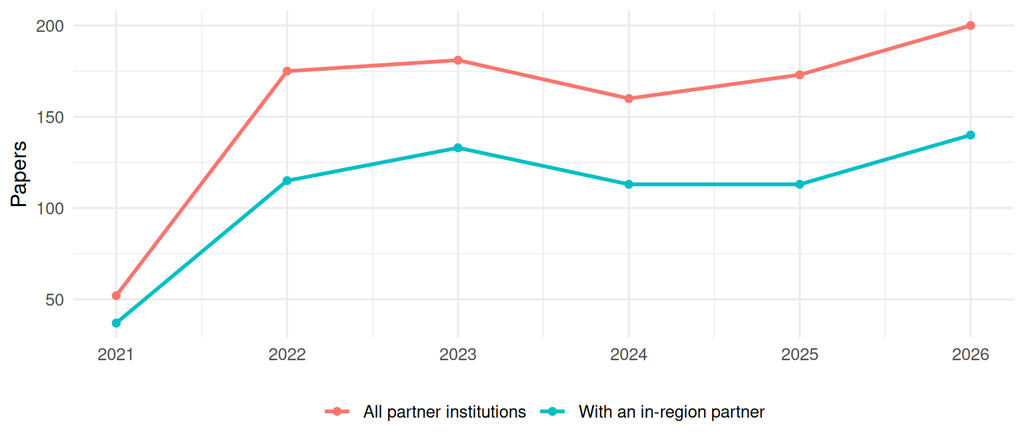

| Partner | Papers in topics |
| --- | --- |
| Woods Hole Oceanographic Institution | 274 |
| University of Rhode Island | 214 |
| Arizona State University | 138 |
| University of Massachusetts-Dartmouth | 116 |
| University of New Hampshire | 107 |
| Gulf of Maine Research Institute | 85 |
| Northeastern University | 76 |
| New Hampshire Sea Grant | 6 |

## Technology base: patents

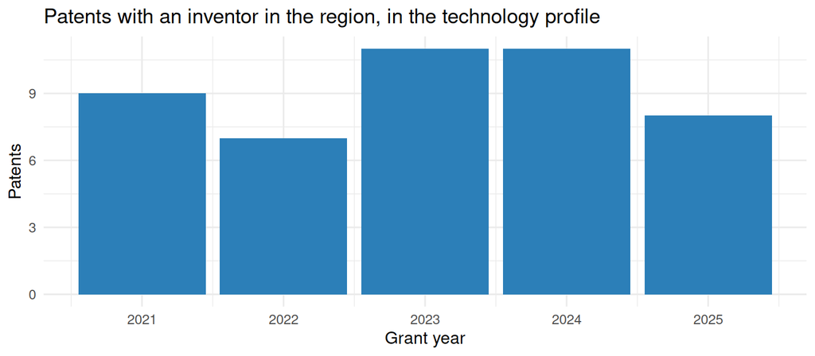

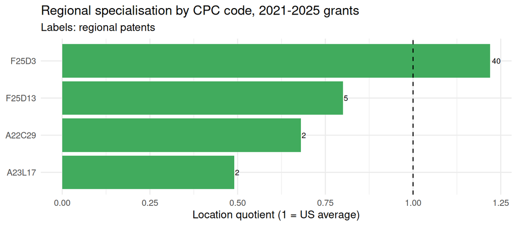

| Assignee | Regional patents in profile |
| --- | --- |
| COLD CHAIN TECHNOLOGIES, LLC | 16 |
| MVE Biological Solutions US, LLC | 3 |
| Packaging Technology Group, LLC | 3 |
| Azenta US, Inc. | 2 |
| Brooks Automation GmbH | 2 |
| Cool Gear International, LLC | 2 |
| Montana Instruments Corporation | 2 |
| Walmart Apollo, LLC | 2 |
| AUSTRALIS AQUACULTURE, LLC | 1 |
| Alert Innovation, Inc. | 1 |

Partner-owned patents invented in the region: 254, of which 0 (0.0%) fall in the Engine’s technology profile.

## Competition

With 46 patents in the technology profile (2021-2025 grants), the Engine’s region would rank **3** among US states; its specialisation (LQ) is 1.024.

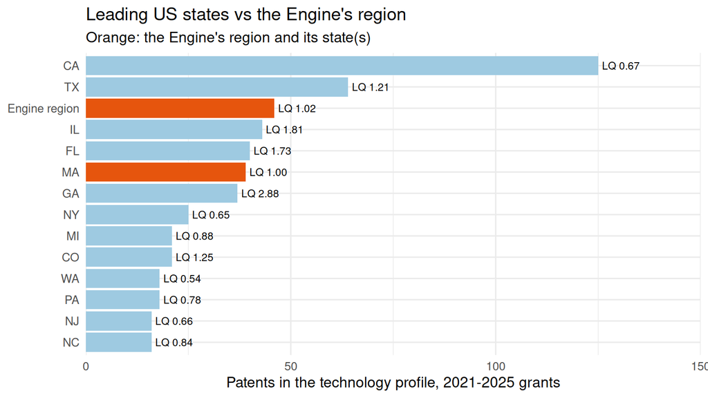

| Country | Share of US patents in profile | Share of world papers in topics |
| --- | --- | --- |
| US | 61.2% | 10.9% |
| CN | 7.5% | 8.2% |
| JP | 7.0% | 2.2% |
| KR | 4.4% | NA |
| GB | 3.9% | 3.9% |
| DE | 3.1% | 2.4% |
| CA | 2.9% | 3.9% |
| FR | 2.0% | 3.5% |
| SE | 1.9% | NA |
| CH | 1.4% | NA |

Patents: inventor countries on US grants in the profile (a patent counts for every country of its inventors). Papers: author countries of OpenAlex works in the Engine’s topics since the window start.

## Data and limitations

- People: PIs and Co-PIs from the NSF Award API; leadership listed on the Engine’s website. Roles come from titles and organisations, revised with OpenAlex evidence.
- Partners: as listed on the Engine’s website, plus organisations of team members. Some Engines publish partner logos without names.
- Region: the Engine’s counties where the list is known (NEO-SMART: 18 Northeast Ohio counties; STELLAR: 11 counties from the NSF abstract), otherwise its states (state-level proxy).
- Technology profile: v3.1 (switch versions in the header). Partner papers and regional patents depend on it: v1 uses mostly CPC subclasses, the v3.1 core uses CPC main groups, which are narrower, so it counts fewer patents and the LQ of a small region rests on few patents.
- Papers: OpenAlex; partner papers are restricted to the Engine’s OpenAlex topics.
- Patents: USPTO grants 2021-2025; inventor locations from PatentsView; pre-grant publications are not included.